# Coursera Practical Machine Learning Project

Zhun Xu

December 25, 2015

## Introduction

This project use the data from accelerometers carried by six participants on their belt, forearm, arm, and dumbell, they were asked to perform barbell lifts correctly and incorrectly in five different ways, this information is also included in the training set as “classe” variable. The goal of this project is to predict the “classe” in which they did the exercise with any of the accelerometers’ data.

## Data and Method

Training and test data of this project are downloaded from following URL  
The training data: https://d396qusza40orc.cloudfront.net/predmachlearn/pml-training.csv  
The test data: https://d396qusza40orc.cloudfront.net/predmachlearn/pml-testing.csv

Both training and test data are first pre-processed to remove variables that are not accelerometers reading data, variables that are near zero, and variables with more than 90% are NULL value. Training data is then splited into ‘mytraining’ and ‘mytesting’ dataset at p=0.7 for training and validation purpose respectively. Since the outcome trying to predict, the “classe” variable is multinomial class data, methods of tree prediction will be employed here to find the best prediction model. I will train the ‘mytraining’ data with six different methods: classification tree, bootstrap aggregating (bagging), random forest, boosting, linear discriminant analysis, and naive bayes, and each resulting model will be validated on ‘mytesting’ data to pick the model with lowerest out-of-sample error. Finally, the picking model will be applied on test data and results are written into .txt file for later submission.

## Data Loading and Pre-processing

### Load Necessary Libraries into R

```r
library(caret)
library(rattle)
library(randomForest)
library(gbm)
library(MASS)
library(klaR)
library(knitr)
```

### Read Data from URL

```r
trainingURL <- "https://d396qusza40orc.cloudfront.net/predmachlearn/pml-training.csv"
training <- read.csv(trainingURL, header=TRUE)
dim(training)
```

```
## [1] 19622   160
```

```r
testingURL <- "https://d396qusza40orc.cloudfront.net/predmachlearn/pml-testing.csv"
testing <- read.csv(testingURL, header=TRUE)
dim(testing)
```

```
## [1]  20 160
```

```r
table(training$classe)
```

```
##
##    A    B    C    D    E
## 5580 3797 3422 3216 3607
```

### Remove Non-Accelerometer Reading Variables

```r
drops <- c("X", "user_name", "raw_timestamp_part_1", "raw_timestamp_part_2", "cvtd_timestamp", "new_window", "num_window")
training <- training[, !(names(training) %in% drops)]
testing <- testing[, !(names(testing) %in% drops)]
```

### Remove Near Zero Variables

```r
nzv <- nearZeroVar(training)
training <- training[, -nzv]
testing <- testing[, -nzv]
```

### Remove Variables with Over 90% of NA Values

```r
NAData <- is.na(training)
Remove <- which(colSums(NAData) > nrow(training)*0.9)
training <- training[, -Remove]
testing <- testing[, -Remove]
```

### Create Training and Validation Sets

```r
set.seed(123)
inTrain <- createDataPartition(y=training$classe, p=0.7, list=FALSE)
mytraining <- training[inTrain, ]
mytesting <- training[-inTrain, ]
dim(mytraining)
```

```
## [1] 13737    53
```

```r
dim(mytesting)
```

```
## [1] 5885   53
```

Original training and test data each contains 160 variables. Data processing removes 107 variables from the original data, keeps 53 variables in the final data set. There are 19622 records in training data, and 13737 are assigned into ‘mytraining’ data and rest 5885 are assigned into ’mytesting’data. The outcome “classe” variable has five class value, A, B, C, D, and E.

## Build Prediction Models

### Classification Tree

```r
set.seed(123)
modFit_rpart <- train(classe ~ ., method="rpart", data=mytraining)
```

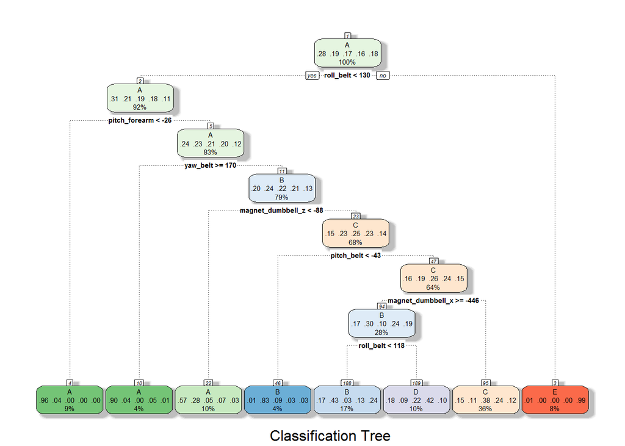

```r
fancyRpartPlot(modFit_rpart$finalModel, sub="Classification Tree")
```

```r
pred_rpart <- predict(modFit_rpart, mytesting)
testing_rpart <- confusionMatrix(pred_rpart, mytesting$classe)
testing_rpart$table
```

```
##           Reference
## Prediction    A    B    C    D    E
##          A 1061  235   27   64   13
##          B  163  631   42  133  281
##          C  341  230  819  509  247
##          D  102   43  138  258   60
##          E    7    0    0    0  481
```

Prediction table of ‘mytesting’ dataset via rpart method shows only classe C is relatively well predicted (79.8% accuracy) under this method, classe A & B are predicted with 63% and 55% correction rate, and classe D & E are predicted at less than 50% correction rate.

### Bootstrap Aggregating

```r
set.seed(123)
modFit_bagging <- train(classe ~ ., method="treebag", data=mytraining)
pred_bagging <- predict(modFit_bagging, mytesting)
testing_bagging <- confusionMatrix(pred_bagging, mytesting$classe)
testing_bagging$table
```

```
##           Reference
## Prediction    A    B    C    D    E
##          A 1667    9    1    0    0
##          B    6 1123    9    0    0
##          C    0    3 1012   21    3
##          D    0    3    4  942    1
##          E    1    1    0    1 1078
```

Results from bootstrap aggregating method show a much better prediction of ‘mytesting’ dataset. Accuracy of prediction ranges from 98% in classe D, 99% in classe B & C, to over 99.5% in classe A & E.

### Random Forest

```r
set.seed(123)
modFit_randomforest <- randomForest(y=mytraining$classe, x=mytraining[,-53], importance=TRUE)
pred_randomforest <- predict(modFit_randomforest, mytesting)
testing_randomforest <- confusionMatrix(pred_randomforest, mytesting$classe)
testing_randomforest$table
```

```
##           Reference
## Prediction    A    B    C    D    E
##          A 1673    5    0    0    0
##          B    1 1134   10    0    0
##          C    0    0 1016   15    0
##          D    0    0    0  948    0
##          E    0    0    0    1 1082
```

### Boosting

```r
set.seed(123)
modFit_boosting <- gbm(classe~., data=mytraining, distribution = 'multinomial', n.trees = 500, interaction.depth = 4)
pred_boosting <- predict(modFit_boosting, mytesting, n.trees=500, type='response')
p.predBST <- LETTERS[apply(pred_boosting, 1, which.max)]
testing_boosting <- confusionMatrix(p.predBST, mytesting$classe)
testing_boosting$table
```

```
##           Reference
## Prediction    A    B    C    D    E
##          A 1347  201   61   61   12
##          B   81  678  105   37  100
##          C   94  164  808  131   85
##          D  122   89   51  697   67
##          E   30    7    1   38  818
```

It seems that boosting method is not the best choice here, highest prediction accuracy is only 80% in classe A and 79% in classe C. Lowest prediction accuracy is 60% in classe B.

### Linear Discriminant Analysis

```r
set.seed(123)
modFit_lda <- train(classe~., data=mytraining, method="lda")
pred_lda <- predict(modFit_lda, mytesting)
testing_lda <- confusionMatrix(pred_lda, mytesting$classe)
testing_lda$table
```

```
##           Reference
## Prediction    A    B    C    D    E
##          A 1374  185  115   49   49
##          B   33  721  111   51  185
##          C  134  144  678  124  105
##          D  128   47  106  694  101
##          E    5   42   16   46  642
```

Linear discriminant analysis method also performs less optimal on prediction of ‘mytesting’ dataset, the prediction accuracy ranges from 59% to 82%.

### Naive Bayes

```r
set.seed(123)
modFit_naivebayes <- train(classe~., data=mytraining, method="nb")
pred_naivebayes <- predict(modFit_naivebayes, mytesting)
testing_naivebayes <- confusionMatrix(pred_naivebayes, mytesting$classe)
testing_naivebayes$table
```

```
##           Reference
## Prediction    A    B    C    D    E
##          A 1469  242  263  187   68
##          B   32  724   60    0  114
##          C   48   95  664  126   40
##          D  117   66   38  609   45
##          E    8   12    1   42  815
```

Naive bayes model predict the ‘mytesting’ dataset at a 63% to 88% correct rate.

## Prediction Model Selection

```r
model.compare <- data.frame(classification.tree=testing_rpart$overall[1],
             bagging=testing_bagging$overall[1],
                 random.forest=testing_randomforest$overall[1],
                 boosting=testing_boosting$overall[1],
                 linear.discriminat.analysis=testing_lda$overall[1],
             naive.bayes=testing_naivebayes$overall[1])
model.compare
```

```
##          classification.tree   bagging random.forest  boosting
## Accuracy           0.5522515 0.9892948     0.9945624 0.7388275
##          linear.discriminat.analysis naive.bayes
## Accuracy                   0.6982158   0.7274427
```

Comparing the out-of-sample errors in above models shows random forest method gives the highest accuracy (99.5%) in ‘mytesting’ dataset prediction. Therefore, we will explore the model built by random forest method further and use this model to test the ‘test’ dataset.

## Detail of Random Forest Model

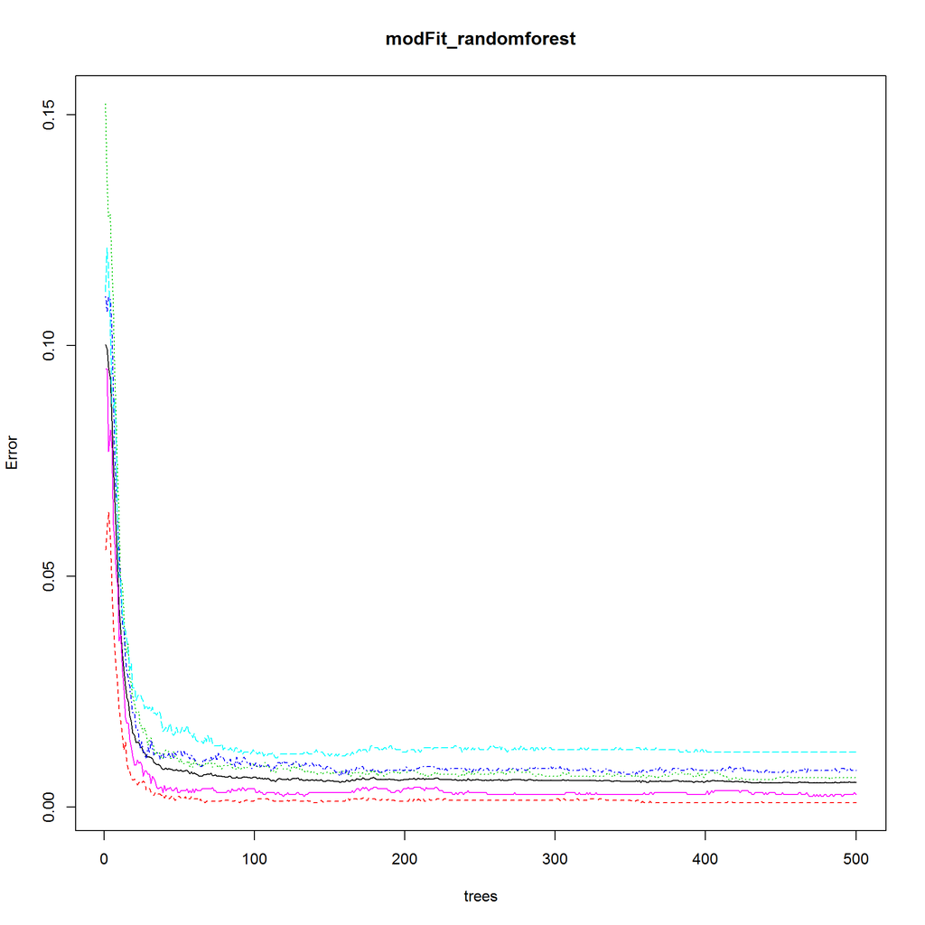

```r
plot(modFit_randomforest)
```

```r
kable(importance(modFit_randomforest))
```

|  | A | B | C | D | E | MeanDecreaseAccuracy | MeanDecreaseGini |
| --- | --- | --- | --- | --- | --- | --- | --- |
| roll_belt | 37.87645 | 48.57686 | 43.57816 | 46.10274 | 39.55759 | 53.22655 | 841.44178 |
| pitch_belt | 31.24147 | 49.00450 | 39.37298 | 32.81634 | 34.83344 | 48.98560 | 481.31492 |
| yaw_belt | 45.65684 | 40.65429 | 42.43108 | 45.38602 | 31.61003 | 58.94505 | 628.42392 |
| total_accel_belt | 14.80469 | 16.69876 | 14.51820 | 14.71149 | 16.17036 | 17.90276 | 158.44886 |
| gyros_belt_x | 18.59814 | 18.06568 | 21.77634 | 14.83921 | 16.62062 | 26.99427 | 70.16683 |
| gyros_belt_y | 12.16395 | 16.55963 | 15.38982 | 14.59286 | 17.16312 | 19.78795 | 81.30199 |
| gyros_belt_z | 20.98223 | 26.77095 | 26.24704 | 21.64418 | 26.43611 | 30.21407 | 210.73852 |
| accel_belt_x | 15.33510 | 17.48389 | 18.74044 | 15.07507 | 16.49113 | 24.38729 | 81.74474 |
| accel_belt_y | 13.01023 | 15.65132 | 14.38151 | 15.50546 | 13.35951 | 18.32497 | 90.17773 |
| accel_belt_z | 18.83852 | 23.41769 | 22.61804 | 22.48595 | 19.32452 | 25.14608 | 290.97826 |
| magnet_belt_x | 18.10845 | 28.20020 | 27.50536 | 21.12326 | 23.72993 | 33.53053 | 178.18060 |
| magnet_belt_y | 21.83845 | 27.90628 | 25.21159 | 25.10223 | 22.87405 | 28.86347 | 277.58911 |
| magnet_belt_z | 22.40902 | 26.55694 | 23.60887 | 27.40011 | 23.61703 | 29.38920 | 280.05002 |
| roll_arm | 20.81823 | 29.87586 | 27.75320 | 28.05639 | 23.30993 | 34.57260 | 215.29825 |
| pitch_arm | 17.66774 | 24.69138 | 21.87214 | 19.16600 | 17.94567 | 25.23174 | 123.56493 |
| yaw_arm | 22.55278 | 26.62330 | 24.20873 | 26.86747 | 20.83170 | 30.81131 | 169.62663 |
| total_accel_arm | 11.81356 | 23.29838 | 20.94736 | 18.79055 | 18.95243 | 24.86022 | 74.55225 |
| gyros_arm_x | 15.82310 | 24.42767 | 17.47450 | 22.01859 | 21.84644 | 24.36525 | 92.83534 |
| gyros_arm_y | 18.91779 | 32.22804 | 20.56479 | 25.02871 | 22.92663 | 36.81231 | 92.04805 |
| gyros_arm_z | 12.35143 | 18.64654 | 15.36454 | 13.30877 | 13.94771 | 23.52531 | 41.67265 |
| accel_arm_x | 16.81513 | 18.34577 | 19.29677 | 22.57238 | 16.34715 | 20.82747 | 171.57312 |
| accel_arm_y | 17.45270 | 22.93079 | 18.35594 | 19.43171 | 17.54254 | 27.76714 | 117.41734 |
| accel_arm_z | 13.67065 | 20.67817 | 21.67404 | 21.62447 | 18.24570 | 22.89479 | 93.24201 |
| magnet_arm_x | 17.29421 | 17.05669 | 19.36081 | 19.30033 | 15.66481 | 19.30657 | 179.81749 |
| magnet_arm_y | 13.88366 | 17.72244 | 18.74456 | 21.41133 | 14.06845 | 18.26887 | 169.85698 |
| magnet_arm_z | 20.66968 | 25.49481 | 25.09696 | 21.65750 | 20.00335 | 29.21246 | 135.26882 |
| roll_dumbbell | 22.94862 | 26.83114 | 28.82744 | 29.42283 | 27.14896 | 30.41208 | 299.28371 |
| pitch_dumbbell | 11.59914 | 19.15110 | 16.89528 | 13.16486 | 14.30828 | 16.74552 | 124.77084 |
| yaw_dumbbell | 18.91165 | 24.35035 | 23.32115 | 21.03968 | 24.45377 | 27.23057 | 177.28643 |
| total_accel_dumbbell | 20.04149 | 23.37688 | 20.53874 | 22.48979 | 24.24486 | 27.09683 | 191.82563 |
| gyros_dumbbell_x | 18.52738 | 26.39370 | 23.41391 | 21.35656 | 21.10162 | 34.10277 | 93.57222 |
| gyros_dumbbell_y | 22.49215 | 22.64911 | 26.29272 | 21.52295 | 19.42740 | 25.74624 | 177.36072 |
| gyros_dumbbell_z | 19.08340 | 23.78178 | 19.67576 | 18.80821 | 16.77399 | 35.09257 | 60.70194 |
| accel_dumbbell_x | 16.75378 | 24.13796 | 20.47036 | 19.28848 | 21.84682 | 24.87552 | 173.17735 |
| accel_dumbbell_y | 26.96405 | 29.48959 | 30.13226 | 28.40378 | 28.42977 | 36.16399 | 281.65363 |
| accel_dumbbell_z | 22.78309 | 26.98153 | 26.97399 | 25.56162 | 28.81470 | 33.23640 | 235.82271 |
| magnet_dumbbell_x | 24.57947 | 27.07363 | 31.40303 | 27.82534 | 24.50222 | 29.90426 | 336.34082 |
| magnet_dumbbell_y | 35.41895 | 36.23958 | 44.32010 | 34.42591 | 30.39574 | 42.48849 | 454.50461 |
| magnet_dumbbell_z | 43.71925 | 39.28291 | 47.57088 | 37.93452 | 36.80561 | 51.51961 | 517.52033 |
| roll_forearm | 28.12279 | 26.29130 | 33.22666 | 23.61706 | 25.67713 | 29.94093 | 411.84995 |
| pitch_forearm | 32.05385 | 33.01934 | 37.57189 | 33.79705 | 34.78353 | 40.74969 | 563.71635 |
| yaw_forearm | 18.00247 | 20.79486 | 21.49645 | 20.64691 | 22.96620 | 28.35049 | 117.21574 |
| total_accel_forearm | 19.09924 | 21.45215 | 19.76855 | 17.71535 | 17.48456 | 26.52478 | 76.95954 |
| gyros_forearm_x | 11.54835 | 18.56086 | 21.22958 | 16.99888 | 16.69743 | 30.56296 | 53.77084 |
| gyros_forearm_y | 16.12599 | 29.39759 | 25.03045 | 22.08270 | 20.79582 | 32.08004 | 88.21212 |
| gyros_forearm_z | 17.52136 | 24.75616 | 22.12356 | 17.40905 | 17.04266 | 31.92442 | 62.80432 |
| accel_forearm_x | 18.56292 | 26.05988 | 25.39990 | 28.41711 | 22.45556 | 26.37568 | 232.44450 |
| accel_forearm_y | 20.65041 | 21.87355 | 23.17302 | 17.66053 | 21.73351 | 28.87496 | 96.34792 |
| accel_forearm_z | 19.11965 | 25.69606 | 24.03782 | 22.87515 | 26.32214 | 30.82037 | 171.35819 |
| magnet_forearm_x | 15.29479 | 19.60763 | 20.31567 | 17.92431 | 18.53395 | 21.04817 | 154.51767 |
| magnet_forearm_y | 21.61939 | 23.44551 | 23.24628 | 22.66772 | 23.10856 | 29.12527 | 156.48976 |
| magnet_forearm_z | 24.04941 | 26.14682 | 24.38401 | 26.09546 | 25.66392 | 32.36979 | 203.65562 |

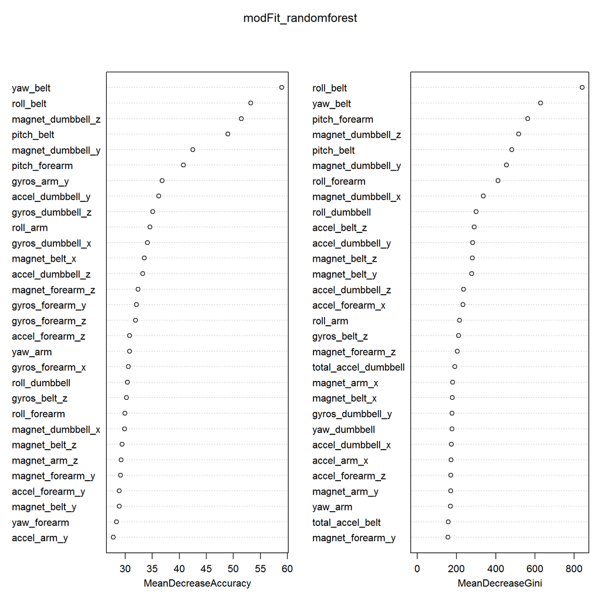

```r
varImpPlot(modFit_randomforest)
```

## Test Prediction and Assignment Output

```r
pred_test <- predict(modFit_randomforest, testing)
submission = function(x){
        n = length(x)
        for(i in 1:n){
                filename = paste0("problem_id_", i, ".txt")
                write.table(x[i], file = filename, quote = FALSE, row.names = FALSE, col.names = FALSE)
        }
}
submission(pred_test)
```